# VGRecommendations_v2_TFIDF

## Let's also have a look into the features

### We will do this by having a quick look into a heatmap

```
(172512, 33)
```

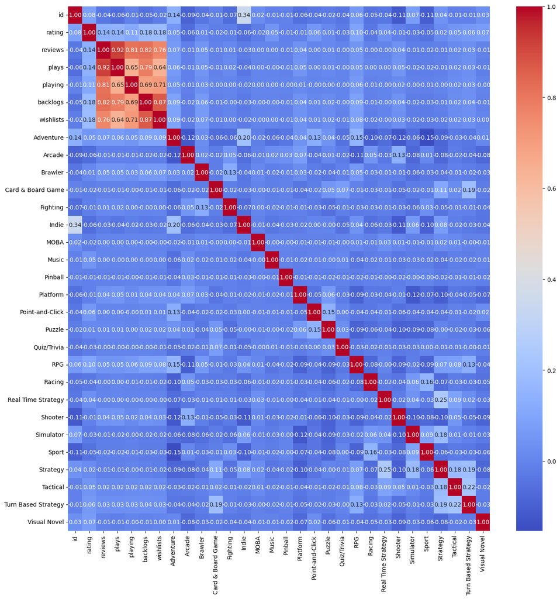

```python
# Drop the 'name' and 'date' columns
df_for_heatmap = merged_df.drop(['name', 'date','description'], axis=1)

# Compute correlations
corr = df_for_heatmap.corr()
print(merged_df.shape)

# Create a heatmap
plt.figure(figsize=(16, 16))
sns.heatmap(corr, annot=True, fmt=".2f", cmap='coolwarm')

plt.show()
```

### Note

Considering the fact that the genres dataset is just 0 and 1 it is not a good idea to try to make a heatmap of everything in the merged df, it does however, help us focus our attention to the games dataset, where we do see some corelation it would seem.

So let us have a look mainly in the games dataset

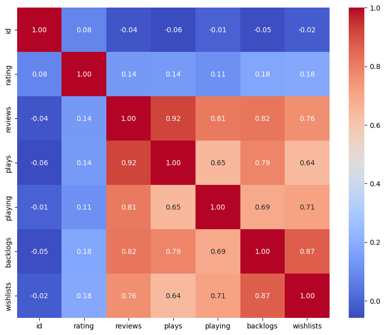

```python
# Drop the 'name' and 'date' columns
df_smaller_heatmap = df_games.drop(['name', 'date','description'], axis=1)

# Compute correlations
corr = df_smaller_heatmap.corr()

# Create a heatmap
plt.figure(figsize=(10, 8))
sns.heatmap(corr, annot=True, fmt=".2f", cmap='coolwarm')

plt.show()
```

I would say that after seeing this we are greeted with a good sign that our recommendation system with work well with the `reviews`,`plays`,`playing`,`backlogs`,`wishlists` columns. After they are recognised from the algorythms as similiar they will probably also be conneceted with a similiar game by the genres either being 1 or 0

## Modeling

```python
from sklearn.feature_extraction.text import TfidfVectorizer

# Initialize the TfidfVectorizer
tfv = TfidfVectorizer(min_df=3,  max_features=None,
                      strip_accents='unicode', analyzer='word', token_pattern=r'\w{1,}',
                        ngram_range=(1, 3), #specify the range of ngrams to use
                        stop_words = 'english') #remove stopwords from the text

# Filling NaNs with empty string to avoid errors
merged_df['description'] = merged_df['description'].fillna('')
```

```python
# Fitting the TF-IDF on the 'description' text
tfv_matrix = tfv.fit_transform(merged_df['description'])

print(tfv_matrix.shape)

# After trying to implement the TFIDF vectorizer, I realized that the sample was too big and I had to reduce it.
sample_df = merged_df.sample(n=60000, random_state=1) # Sampling rows for a the vectorizer

tfv_matrix_sample = tfv.fit_transform(sample_df['description'])

print(tfv_matrix_sample.shape)
```

```
(172512, 480246)
(60000, 123159)
```

## Now we have our descriptions as vectors and they are ready to be used

Note 1: The dataset is just too big for our first try - 172,512 / 480 246

Note 2: Sample 10 000 - gives - (10 000, 17 932)

Note 3: Sample 25 000 - gives - (25 000, 45 929)

Note 4: Sample 50 000 - gives (50 000, 99 374) - loaded for quite a while - VS Code crashed

## Sigmoid kernel

What does it do - it is resposible for transofming all of the values to be between 0 to 1

Aftwerwards, with respect to the previous overview, which in our case is a sentance, compares it to another overview(sentance). After it does so, it will give us a value between 0 and 1

Only after we give the combination of same matrixes, then and only then can the proper comparing be done

```python
from sklearn.metrics.pairwise import sigmoid_kernel

# Compute the sigmoid kernel
sig = sigmoid_kernel(tfv_matrix_sample, tfv_matrix_sample)
```

Let us check the first Line

```python
sig[0]
```

```
array([0.76159757, 0.76159419, 0.76159416, ..., 0.76159416, 0.76159419,
       0.76159416])
```

### Reverse mapping of indices and game names - using sampled df

```python
indices = pd.Series(sample_df.index, index=sample_df['name']).drop_duplicates()
```

```python
indices
```

```
name
Pursuit Force: Extreme Justice                                         39078
Cuphead: Physical Edition                                             124919
Vs. TKO Boxing                                                          4893
Arcane: The Armor Collector                                           163263
Sabre Wulf                                                             27423
                                                                       ...
The Legend of Zelda: Majora's Mask 3D - Collector's Edition            65921
What Comes After                                                      104195
Of Blades & Tails                                                     123434
Family Trainer: Rai-rai Kyonshis - Baby Kyonshi no Amida Daibouken      6772
Hotlap Heroes                                                          90986
Length: 60000, dtype: int64
```

## Let's try to create a function that will give us a proper recomendation

```python
def give_rec(name, sig=sig):
    # Get the index of the corresponding game, based on the name that is provided
    idx = indices[name]

    # We create a list of all of the values
    #This is done by making it so that each value in the list consist of the index and the sigmoid value that it has
    # Get the pairwsie similarity scores
    sig_scores = list(enumerate(sig[idx]))

    # Sort the games in accesnding order, so that the highest scores are first
    # This way the games that are the most similar will be at the top
    sig_scores = sorted(sig_scores, key=lambda x: x[1], reverse=True)

    # Scores of the 5 most similar games
    sig_scores = sig_scores[1:6]

    # Game indices
    game_indices = [i[0] for i in sig_scores]

    # Top 5 most similar games
    return sample_df['name'].iloc[game_indices]
```

Make a quick test try it out first

```python
give_rec('Pursuit Force: Extreme Justice')
```

```
71493    Yoiyami Dreamer: Voice of the Dreambringer
14430                                         Goice
18108                                      Airgrave
64970                    Alia's Carnival! Sacrament
4750                                      Garyuu-ou
Name: name, dtype: object
```

After trying to do so with the game `Dogs++`, we receive the following error **index 170737 is out of bounds for axis 0 with size 60000**

The programm can run, However there are a couple of things that need to be taken into consideration

```
- The sampled dataset for the TFIDF and Sigmoid Kergel needs to be the same as the dataset
- The whole dataset currently needs to be cleaned
- The whole merged dataset probably needs to be slimmed down somewhere around 60000 ~ 70000 (I am guessing my machines limits) rows
```